# Random Forest Modelling of the Lake Erie microbial community

Author: Michelle Berry

Date: 2/24/15

This is some sample code of how to run both regression and classification random forest models with microbial community composition datasets.

In this example, we are working with illumina 16s data that has already been processed into an otu and taxonomy table. The samples were collected from Western Lake Erie between May and November 2014 at three different locations. Bacterial DNA was extracted from three types of samples:

1. Full community samples: whole lake water was syringe-filtered onto a .22um PES filter to represent the “full” bacterial community (yes i know there are picoplankton that are smaller than .22um).
2. Algal/particle: This fraction targets cyanobacterial colonies and attached bacteria. Whole lake water was passed through a 100um mesh and the retentate was then filtered onto a glass fiber filter.
3. Free-living bacteria: This fraction targets just the free-living bacteria, which we defined as anything between 3um and .22um. Lake water was prefiltered through a 53um mesh and then passed through 3um and .22 um filters.

## Data Import

```r
# Load libraries
library(phyloseq)
packageVersion("phyloseq")
```

```
## [1] '1.10.0'
```

```r
library(ggplot2)
library(reshape2)
library(plyr)
library(scales)
library(knitr)
library(randomForest)

# Set working directory
setwd("~/habs/genomics/data/")

# mothur file import
sharedfile = "mothur/furthestneighbor.shared"
taxfile = "mothur/furthestneighbor.taxonomy"
mothurdata = import_mothur(mothur_shared_file = sharedfile ,
                           mothur_constaxonomy_file = taxfile )
mothurdata
```

```
## phyloseq-class experiment-level object
## otu_table()   OTU Table:         [ 15633 taxa and 221 samples ]
## tax_table()   Taxonomy Table:    [ 15633 taxa by 6 taxonomic ranks ]
```

```r
# Taxonomy names are listed as Rank1, Rank2 . . .
colnames(tax_table(mothurdata))
```

```
## [1] "Rank1" "Rank2" "Rank3" "Rank4" "Rank5" "Rank6"
```

```r
# Change to Kingdom, Phylum . . .
colnames(tax_table(mothurdata)) <- c("Kingdom","Phylum","Class","Order","Family","Genus")

# Import metadata and merge with other object
metadata = "other/metadata_bloom.txt"
map = import_qiime_sample_data(metadata)
map1 <-map[-1,]
colnames(otu_table(mothurdata))<-map1$SampleID
moth_merge = merge_phyloseq(mothurdata,map)

# What variables are in our metadata?
sample_variables(moth_merge)
```

```
##  [1] "SampleID"       "Samplenum"      "Date"           "DateContinuous"
##  [5] "Station"        "Fraction"       "Photonum"       "pH"
##  [9] "Type"           "Intensive"      "Arrival"        "Departure"
## [13] "Sky"            "StationDepth"   "Secchi"         "Temp"
## [17] "Turbidity"      "ParMC"          "DissMC"         "Phycocyanin"
## [21] "Chla"           "Bloom"          "LogPhyco"       "LogChla"
## [25] "LogParMC"
```

```r
# lets filter out samples such as blanks, mock communities and samples that didnt amplify
moth_good <- subset_samples(moth_merge,Type=="sample" & Intensive=="n")
moth_good <- subset_taxa(moth_good,
                         Kingdom == "Bacteria" &
                         Class != "Chloroplast" &
                        Family!="mitochondria"
                          )
moth_good <- prune_taxa(taxa_sums(moth_good)>0,moth_good)
moth_good
```

```
## phyloseq-class experiment-level object
## otu_table()   OTU Table:         [ 11765 taxa and 174 samples ]
## sample_data() Sample Data:       [ 174 samples by 25 sample variables ]
## tax_table()   Taxonomy Table:    [ 11765 taxa by 6 taxonomic ranks ]
```

## Classification rf: modelling algal-associated vs free-living

For this random forest we want to build a model which will classify samples as either “free-living” or “algal/particle”. In doing this, we will also pull out which OTUs seem to be associated with the free-living lifestyle, vs attachment to colonial algae

First, we need to do a few things to filter our data and put it in the right format

```r
# Select only samples of type 100L (Algal/particle) or 22NA (free-living)
moth_subset<-subset_samples(moth_good,Fraction=="100L"|Fraction=="22NA")

# Normalize read counts by scaling to smallest library size
moth_scaled<-scale_reads(moth_subset,min(sample_sums(moth_subset)))
```

Lets make some barplots to get a sense of what these communities look like. Here is a barplot of phylum composition from all three locations (WE2, WE12, WE4)

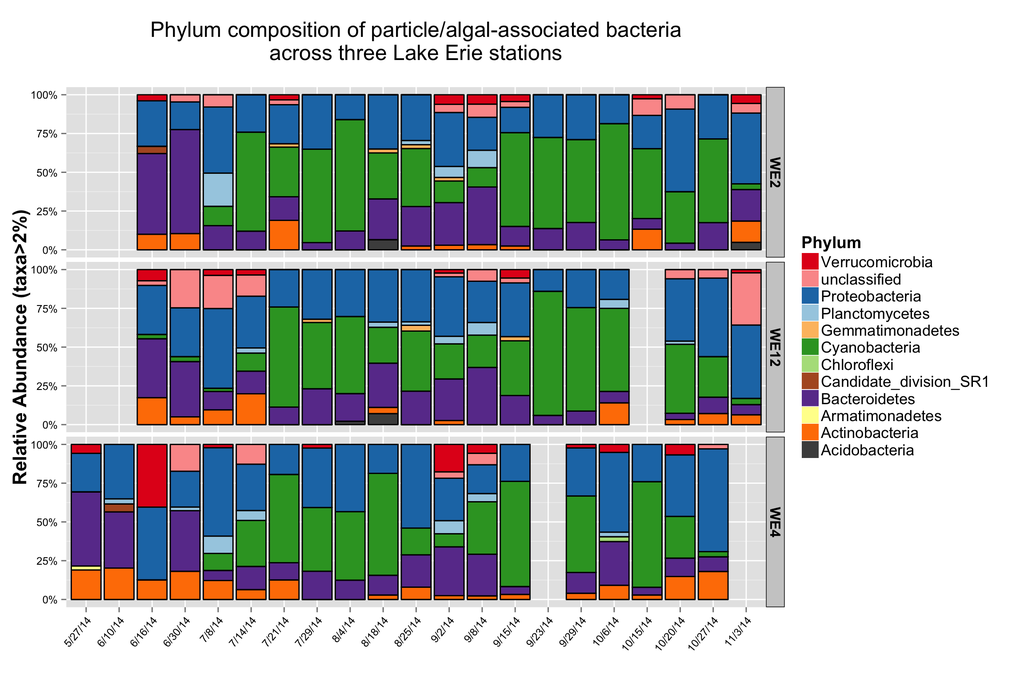

```r
# Plot phylum level composition of Particle/algal fraction
F100L <- subset_samples(moth_scaled,Fraction=="100L")

# Set Colors (RColorBrewer)
phy <- c(Acidobacteria="#4D4D4D",Actinobacteria="#ff7f00",Armatimonadetes="#ffff99",
         Bacteroidetes="#6a3d9a",Candidate_division_SR1 ="#b15928" ,
         Chlorobi="#cab2d6", Chloroflexi="#B2DF8A",
         Chloroplast="darkgreen",Cyanobacteria="#33A02C",
         Gemmatimonadetes="#fdbf6f",Planctomycetes="#A6CEE3",
         Proteobacteria="#1F78B4", unclassified="#fb9a99",
         Verrucomicrobia ="#e31a1c")

F100L.long<-transform_and_melt(physeq = F100L,taxrank = "Phylum",prune = .02)

make_tax_barplot(df = F100L.long,x = "Date",tax = "Phylum",
                 title = "Phylum composition of particle/algal-associated bacteria
across three Lake Erie stations\n",
                 colors=phy,
                 xlab="",
                 ylab="Relative Abundance (taxa>2%)")
```

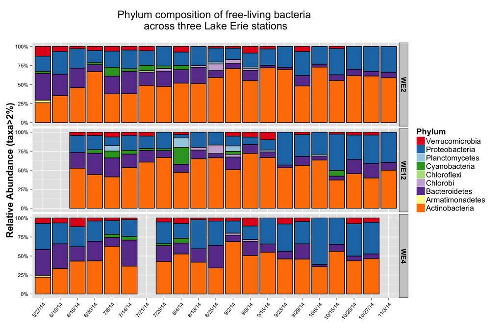

```r
# Plot phylum level composition of Free-living fraction
F22NA <- subset_samples(moth_scaled,Fraction=="22NA")

F22NA.long<-transform_and_melt(physeq = F22NA,taxrank = "Phylum",prune = .02)

make_tax_barplot(df = F22NA.long,x = "Date",tax = "Phylum",
                 title = "Phylum composition of free-living bacteria
across three Lake Erie stations\n",
                 colors=phy,
                 xlab="",
                 ylab="Relative Abundance (taxa>2%)")
```

Here is an NMDS of the samples colored by free-living or particle/algal. We can already see vsee that these communities are very well segregated, so our random forest model will probably work very well.

```r
# Make an NMDS colored by sample type
# Plot NMDS
theme_set(theme_bw())
bray.nmds = ordinate(moth_scaled,method="NMDS","bray")
```

```
## Square root transformation
## Wisconsin double standardization
```

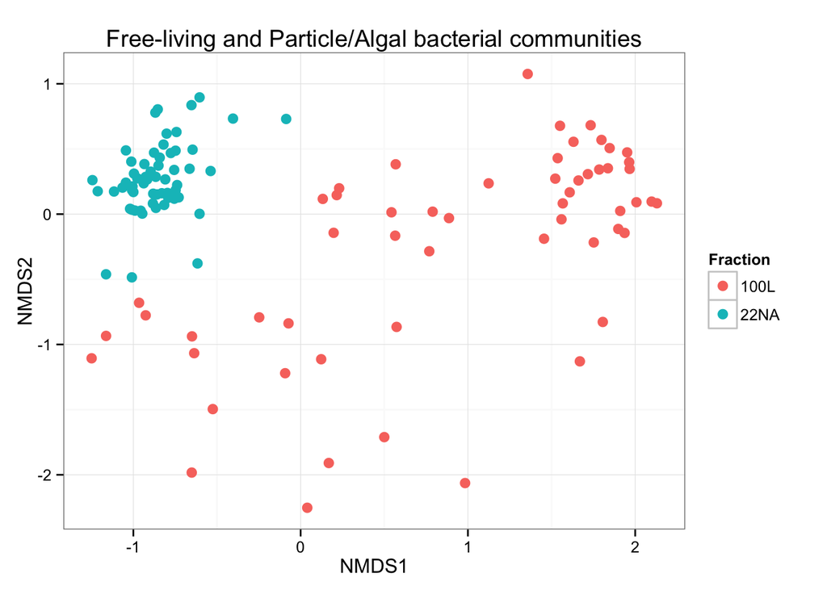

```r
plot_ordination(moth_scaled,bray.nmds,color = "Fraction") +
  geom_point(size=3) +
  ggtitle("Free-living and Particle/Algal bacterial communities")
```

```r
# Make a dataframe of training data with OTUs as column and samples as rows
t_otu <- t(otu_table(moth_scaled))
dim(t_otu)
```

```
## [1] 115 788
```

We have 115 samples and 788 OTUs

```r
# Make one column for our predictor variable "Fraction"
Fraction <- as.factor(sample_data(moth_scaled)$Fraction)

# Combine them into 1 data frame
rf_data<-data.frame(Fraction,t_otu)
```

Now we will use the randomForest package to train and test our random forest model using the “out of bag” error to estimate our model error. OOB is a nice feature of random forest models whereby since the training data is bootstrapped, you only use approximately 2/3 of the data at each iteration. The remaining 1/3 or “out of bag” data can be used to validate your model. This removes the need to use another form of cross-validation such as using a separate validation set or k-folds.

### Results

```r
# It is important to set a seed for reproducability
# By default, randomForest uses p/3 variables when building
# a random forest of regression trees and root(p)
# variables when building a random forest of classification trees.
# In this case, root(p) = 28
set.seed(1)
rf.erie <- randomForest(Fraction~.,data=rf_data,ntree=100)
print(rf.erie)
```

```
##
## Call:
##  randomForest(formula = Fraction ~ ., data = rf_data, ntree = 100)
##                Type of random forest: classification
##                      Number of trees: 100
## No. of variables tried at each split: 28
##
##         OOB estimate of  error rate: 1.74%
## Confusion matrix:
##      100L 22NA class.error
## 100L   56    0  0.00000000
## 22NA    2   57  0.03389831
```

Our out of bag error is 1.74%

```r
# What variables are stored in the output?
names(rf.erie)
```

```
##  [1] "call"            "type"            "predicted"
##  [4] "err.rate"        "confusion"       "votes"
##  [7] "oob.times"       "classes"         "importance"
## [10] "importanceSD"    "localImportance" "proximity"
## [13] "ntree"           "mtry"            "forest"
## [16] "y"               "test"            "inbag"
## [19] "terms"
```

This model worked really well! We can very accurately classify our bacterial communities into free-living or particle/algal-associated

### plots

Lets make some plots of the most important variables in our model

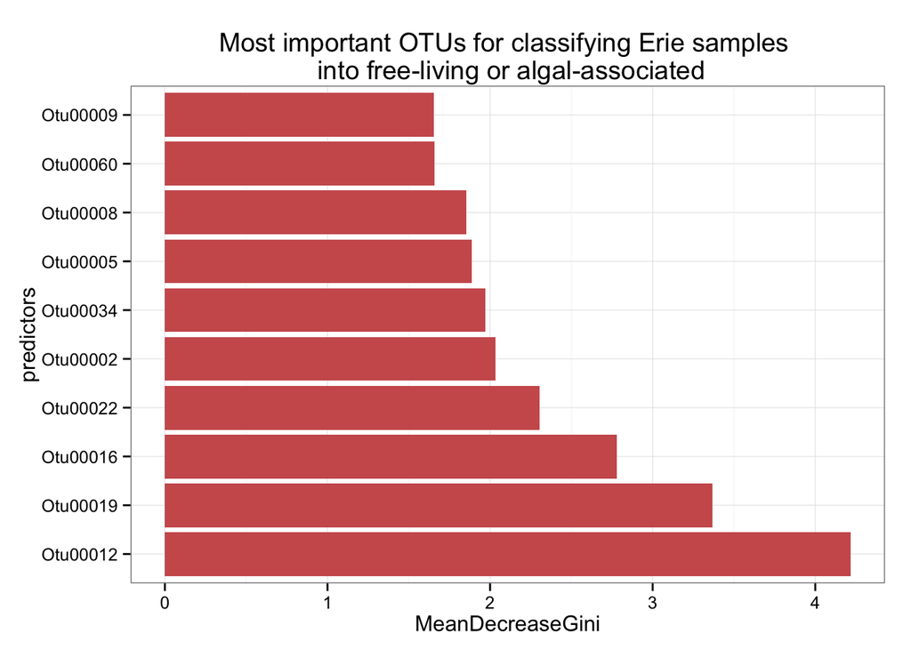

```r
# Select the importance vactor for the predictors.
# For a regression tree this is measured by mean decrease in MSE
# due to that variable
imp <- importance(rf.erie)
imp <- data.frame(predictors=rownames(imp),imp)

# Order the predictor levels by importance
imp.sort <- arrange(imp,desc(MeanDecreaseGini))
imp.sort$predictors <- factor(imp.sort$predictors,levels=imp.sort$predictors)

# Select the top 10 predictors
imp.10<- imp.sort[1:10,]


# ggplot
ggplot(imp.10,aes(x=predictors,y=MeanDecreaseGini))+
  geom_bar(stat="identity",fill="indianred") +
  coord_flip()+
  ggtitle("Most important OTUs for classifying Erie samples \n into free-living or algal-associated")
```

```r
# What are those OTUs?
otunames<- imp.10$predictors
r <- rownames(tax_table(moth_scaled)) %in% otunames
kable(tax_table(moth_scaled)[r,])
```

|  | Kingdom | Phylum | Class | Order | Family | Genus |
| --- | --- | --- | --- | --- | --- | --- |
| Otu00002 | Bacteria | Actinobacteria | Actinobacteria | Frankiales | Sporichthyaceae | hgcI_clade |
| Otu00005 | Bacteria | Cyanobacteria | Cyanobacteria | SubsectionI | FamilyI | Microcystis |
| Otu00008 | Bacteria | Actinobacteria | Actinobacteria | Frankiales | Sporichthyaceae | unclassified |
| Otu00009 | Bacteria | Actinobacteria | Actinobacteria | Frankiales | Sporichthyaceae | hgcI_clade |
| Otu00012 | Bacteria | Proteobacteria | Betaproteobacteria | Burkholderiales | Oxalobacteraceae | unclassified |
| Otu00016 | Bacteria | Actinobacteria | Actinobacteria | Frankiales | Sporichthyaceae | Candidatus_Planktophila |
| Otu00019 | Bacteria | Proteobacteria | Betaproteobacteria | Methylophilales | Methylophilaceae | LD28_freshwater_group |
| Otu00022 | Bacteria | Actinobacteria | Actinobacteria | Frankiales | Sporichthyaceae | hgcI_clade |
| Otu00034 | Bacteria | Proteobacteria | Alphaproteobacteria | Rhodobacterales | Rhodobacteraceae | Rhodobacter |
| Otu00060 | Bacteria | Proteobacteria | Betaproteobacteria | Burkholderiales | Alcaligenaceae | MWH-UniP1_aquatic_group |